# **BInary Tree**

**Binary tree**

merupakan tree dimana setiap parent hanya memiliki dua buah atau satu node children saja. Karena didalam binary tree terdiri node dimana setiap node memiliki informasi mengenai nilai node dan edge (method untuk menambahkan node baru pada tree), maka tree ataupun binary tree ini akan lebih mudah diimplementasikan dengan menggunakan tipe data class. Representasi binary tree dapat dilihat pada Gambar 3 berikut.

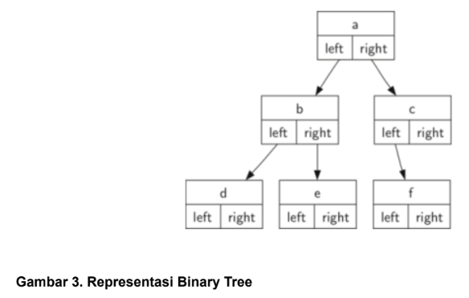

**Code**

Berikut implementasi class binary Tree, dimana pada class ini terdapat tiga buah property atau state, yaitu key, leftChild, dan rightChild. Key digunakan untuk informasi nilai yang terdapat pada node, lefchild dan rightchild digunakan sebagai pointer untuk menunjukkan child sebelah kiri dan kanan dari node.

```python
class BinaryTree:
    def __init__(self, root):
        self.key = root
        self.leftChild = None
        self.rightChild = None
```

```python
myTree=BinaryTree(10)
print(myTree.leftChild)
```

### **CODE**

Pada class yang sudah dibuat tersebut, terdapat suatu constructor, yaitu node akan dibuat setiap sebuah object didefinisikan dengan menggunakan tipe data class BinaryTree ini. Class BinaryTree ini harus memiliki dua method utama yaitu, insertLeft dan insertRight. Pada method insertLeft ini, sebuah subtree akan dibuat, dan dilekatkan terhadap tree utama dari edge root yang sebelah kiri, begitu juga insertRight.

```python
class BinaryTree:
    def __init__(self, root):
        self.key = root
        self.leftChild = None
        self.rightChild = None
    def insertLeft(self, new_node):
        if self.leftChild == None:
            self.leftChild = BinaryTree(new_node)
        else:
            t = BinaryTree(new_node)
            t.leftChild = self.leftChild
            self.leftChild = t
    def insertRight(self, new_node):
        if self.rightChild == None:
            self.rightChild = BinaryTree(new_node)
        else:
            t = BinaryTree(new_node)
            t.rightChild = self.rightChild
            self.rightChild = t
```

Pada method insertLeft tersebut perlu dilakukan pemeriksaan terlebih dahulu, apakah child kiri dari node yang akan disisipi subtree baru masih kosong, jika iya maka subtree tersebut dimasukkan pada leftChild. Ilustrasi insertLeft pada suatu binary tree yang pointer leftchild masih kosong, dapat dilihat pada Gambar 3. Misalkan tree 't' akan disisipkan pada tree 'a', dimana leftchild dari tree a, masih kosong, sehingga dapat langsung diperintahkan :

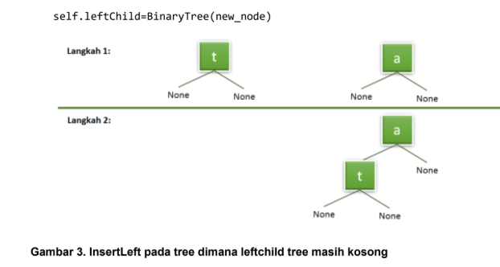

Jika penyisipan dilakukan pada suatu binary tree, dimana leftchild tree tersebut tidak kosong. Misalkan terdapat tree 'a', dimana tree 'a' tersebut, memiliki leftchild, yaitu 'b'. Jika ingin dilakukan penyisipan tree baru, yaitu 't', maka tahapan yang harus dilakukan adalah :

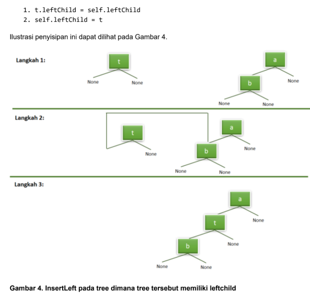

Perintah pada baris pertama digunakan agar node yang terletak pada left child tetap ada dan tidak hilang. Jika perintah tersebut dibalik menjadi :

1. self.leftChild = t
2. t.leftChild = self.leftChild

Maka node yang merupakan leftchild dari node utama akan hilang, karena tidak ada pointer yang menunjuk ke leftchild tersebut. Ilustrasi ini dapat dilihat pada Gambar 5.

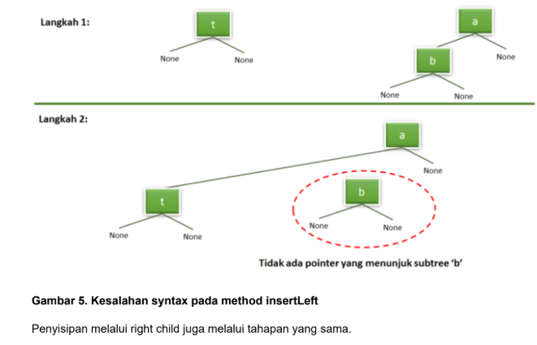

**Code**

Berikut tambahan method pada class BinaryTree, untuk mendapatkan informasi mengenai left child, right child, dan root dari suatu binary tree.

```python
class BinaryTree:
    def __init__(self, root):
        self.key = root
        self.leftChild = None
        self.rightChild = None
    def insertLeft(self, new_node):
        if self.leftChild == None:
            self.leftChild = BinaryTree(new_node)
        else:
            t = BinaryTree(new_node)
            t.leftChild = self.leftChild
            self.leftChild = t
    def insertRight(self, new_node):
        if self.rightChild == None:
            self.rightChild = BinaryTree(new_node)
        else:
            t = BinaryTree(new_node)
            t.rightChild = self.rightChild
            self.rightChild = t
    def getRightChild(self):
        return self.rightChild
    def getLeftChild(self):
        return self.leftChild
    def setRootVal(self, obj):
        self.key = obj
    def getRootVal(self):
        return self.key
```

## **BINARY TREE W3**

Pohon adalah struktur data hierarkis yang terdiri dari simpul-simpul yang dihubungkan oleh sisi-sisi.

Setiap node berisi sebuah nilai dan referensi ke node anaknya.

## **Pohon Biner**

Pohon Biner adalah jenis struktur data pohon di mana setiap simpul dapat memiliki maksimal dua simpul anak, yaitu simpul anak kiri dan simpul anak kanan.

Pembatasan ini, bahwa sebuah node hanya dapat memiliki maksimal dua node anak, memberikan kita banyak manfaat:

- Algoritma seperti penelusuran, pencarian, penyisipan, dan penghapusan menjadi lebih mudah dipahami, diimplementasikan, dan dijalankan lebih cepat.
- Menjaga agar data tetap terurut dalam Pohon Pencarian Biner (BST) membuat pencarian menjadi sangat efisien.
- Menyeimbangkan pohon lebih mudah dilakukan dengan jumlah node anak yang terbatas, misalnya menggunakan Pohon Biner AVL.
- Pohon biner dapat direpresentasikan sebagai array, sehingga pohon menjadi lebih hemat memori.

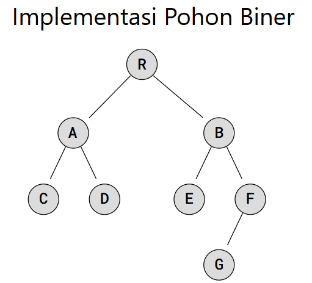

Pohon Biner di atas dapat diimplementasikan seperti halnya Linked List , kecuali bahwa alih-alih menghubungkan setiap node ke satu node berikutnya, kita membuat struktur di mana setiap node dapat dihubungkan ke node anak kiri dan kanannya.

```python
# ContohDapatkan server Python Anda sendiri
# Membuat Pohon Biner di Python:

class TreeNode:
  def __init__(self, data):
    self.data = data
    self.left = None
    self.right = None

root = TreeNode('R')
nodeA = TreeNode('A')
nodeB = TreeNode('B')
nodeC = TreeNode('C')
nodeD = TreeNode('D')
nodeE = TreeNode('E')
nodeF = TreeNode('F')
nodeG = TreeNode('G')

root.left = nodeA
root.right = nodeB

nodeA.left = nodeC
nodeA.right = nodeD

nodeB.left = nodeE
nodeB.right = nodeF

nodeF.left = nodeG

# Test
print("root.right.left.data:", root.right.left.data)
```

## **Jenis-jenis Pohon Biner**

Terdapat berbagai varian, atau tipe, Pohon Biner yang layak dibahas untuk mendapatkan pemahaman yang lebih baik tentang bagaimana Pohon Biner dapat disusun.

Berbagai jenis Pohon Biner juga perlu disebutkan sekarang karena kata-kata dan konsep ini akan digunakan nanti dalam tutorial ini.

Di bawah ini adalah penjelasan singkat tentang berbagai jenis struktur Pohon Biner, dan di bawah penjelasan tersebut terdapat gambar-gambar dari jenis struktur tersebut agar mudah dipahami.

Pohon Biner yang seimbang memiliki perbedaan paling banyak 1 antara tinggi subpohon kiri dan kanannya, untuk setiap simpul dalam pohon tersebut.

Pohon Biner yang lengkap memiliki semua level yang terisi penuh dengan node, kecuali level terakhir, yang juga bisa terisi penuh, atau diisi dari kiri ke kanan. Sifat-sifat Pohon Biner yang lengkap berarti pohon tersebut juga seimbang.

Pohon Biner penuh adalah jenis pohon di mana setiap simpul memiliki 0 atau 2 simpul anak.

Pohon Biner Sempurna memiliki semua simpul daun pada level yang sama, yang berarti bahwa semua level penuh dengan simpul, dan semua simpul internal memiliki dua simpul anak. Sifat-sifat Pohon Biner Sempurna juga berarti pohon tersebut penuh, seimbang, dan lengkap.

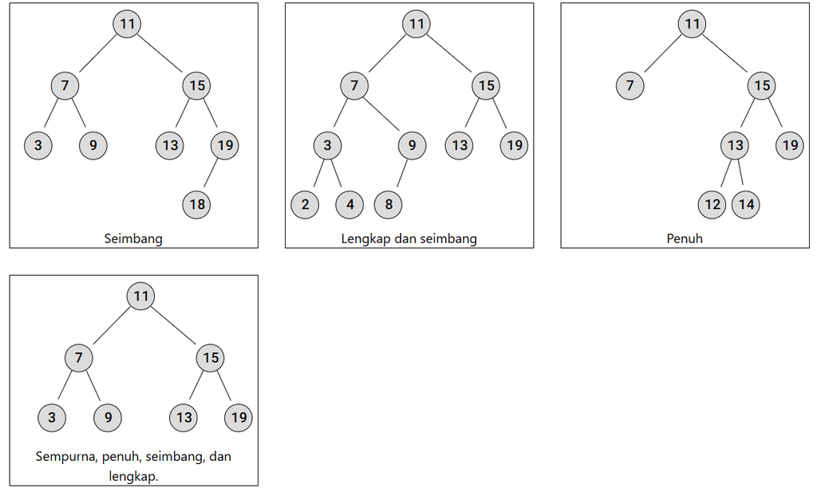

## **Penelusuran Pohon Biner**

Menjelajahi sebuah pohon dengan mengunjungi setiap simpulnya satu per satu disebut traversal.

Karena Array dan Linked List adalah struktur data linier, hanya ada satu cara yang jelas untuk menelusurinya: mulai dari elemen atau node pertama, dan terus kunjungi elemen berikutnya hingga Anda mengunjungi semuanya.

Namun karena sebuah pohon dapat bercabang ke berbagai arah (non-linier), ada berbagai cara untuk menelusuri pohon tersebut.

Ada dua kategori utama metode penelusuran pohon:

**Breadth First Search (BFS)** adalah metode di mana node pada level yang sama dikunjungi terlebih dahulu sebelum beralih ke level berikutnya dalam pohon. Ini berarti pohon dieksplorasi ke arah yang lebih menyamping.

**Pencarian Mendalam Pertama (Depth First Search/DFS)** adalah ketika penelusuran bergerak ke bawah pohon hingga ke simpul daun, menjelajahi cabang pohon satu per satu ke arah bawah.

Ada tiga jenis penelusuran DFS yang berbeda:

# **Penelusuran Pre-order pada Pohon Biner**

Penelusuran Pre-order adalah jenis Pencarian Mendalam (Depth First Search), di mana setiap node dikunjungi dalam urutan tertentu.

Penelusuran pre-order dilakukan dengan mengunjungi node akar terlebih dahulu, kemudian secara rekursif melakukan penelusuran pre-order pada subpohon kiri, diikuti dengan penelusuran pre-order rekursif pada subpohon kanan. Metode ini digunakan untuk membuat salinan pohon, notasi prefiks dari pohon ekspresi, dan lain sebagainya.

Penelusuran ini adalah penelusuran "pre-order" karena simpul tersebut dikunjungi "sebelum" penelusuran pre-order rekursif dari subpohon kiri dan kanan.

Berikut tampilan kode untuk penelusuran pre-order:

```python
# Contoh
# Penelusuran pre-order:

def preOrderTraversal(node):
  if node is None:
    return
  print(node.data, end=", ")
  preOrderTraversal(node.left)
  preOrderTraversal(node.right)
```

Node pertama yang akan dicetak adalah node R, karena Pre-order Traversal bekerja dengan terlebih dahulu mengunjungi, atau mencetak, node saat ini (baris 4), sebelum memanggil node anak kiri dan kanan secara rekursif (baris 5 dan 6).

Fungsi tersebut preOrderTraversal()terus menelusuri subpohon kiri secara rekursif (baris 5), sebelum melanjutkan menelusuri subpohon kanan (baris 6). Jadi node berikutnya yang dicetak adalah 'A' dan kemudian 'C'.

Argumen pertama kali nodemuncul Noneketika anak kiri dari node C diberikan sebagai argumen (C tidak memiliki anak kiri).

Setelah Nonedikembalikan pertama kali saat memanggil anak kiri C, anak kanan C juga mengembalikan None, dan kemudian panggilan rekursif terus menyebar kembali sehingga anak kanan A, D, adalah yang berikutnya yang akan dicetak.

Kode tersebut terus menyebar ke belakang sehingga node-node lainnya di subpohon kanan R dapat dicetak.

# **Penelusuran In-order pada Pohon Biner**

In-order Traversal adalah jenis Depth First Search, di mana setiap node dikunjungi dalam urutan tertentu.

Penelusuran In-order melakukan penelusuran In-order rekursif pada subpohon kiri, mengunjungi simpul akar, dan akhirnya, melakukan penelusuran In-order rekursif pada subpohon kanan. Penelusuran ini terutama digunakan untuk Pohon Pencarian Biner (Binary Search Tree) di mana ia mengembalikan nilai dalam urutan menaik.

Yang membuat penelusuran ini "berurutan" adalah karena simpul tersebut dikunjungi di antara panggilan fungsi rekursif. Simpul tersebut dikunjungi setelah Penelusuran Berurutan (In-order Traversal) dari subpohon kiri, dan sebelum Penelusuran Berurutan (In-order Traversal) dari subpohon kanan.

Berikut tampilan kode untuk In-order Traversal:

```python
# Contoh
# Buat Penelusuran In-order:
def inOrderTraversal(node):
  if node is None:
    return
  inOrderTraversal(node.left)
  print(node.data, end=", ")
  inOrderTraversal(node.right)
```

Fungsi tersebut inOrderTraversal()terus memanggil dirinya sendiri dengan node anak kiri saat ini sebagai argumen (baris 4) hingga argumen tersebut bernilai benar Nonedan fungsi tersebut mengembalikan nilai (baris 2-3).

Argumen pertama kali nodemuncul Noneketika anak kiri dari node C diberikan sebagai argumen (C tidak memiliki anak kiri).

Setelah itu, databagian dari node C dicetak (baris 5), yang berarti bahwa 'C' adalah hal pertama yang dicetak.

Kemudian, anak kanan node C diberikan sebagai argumen (baris 6), yaitu None, sehingga panggilan fungsi kembali tanpa melakukan hal lain.

Setelah 'C' dicetak, inOrderTraversal()panggilan fungsi sebelumnya terus berjalan, sehingga 'A' dicetak, kemudian 'D', lalu 'R', dan seterusnya.

# **Penelusuran Post-order pada Pohon Biner**

Penelusuran Post-order adalah jenis Pencarian Mendalam (Depth First Search), di mana setiap node dikunjungi dalam urutan tertentu.

Penelusuran Post-order bekerja dengan melakukan penelusuran Post-order secara rekursif pada subpohon kiri dan subpohon kanan, diikuti dengan kunjungan ke simpul akar. Metode ini digunakan untuk menghapus pohon, notasi post-fix pada pohon ekspresi, dan lain sebagainya.

Yang membuat penelusuran ini disebut "post" adalah bahwa kunjungan ke sebuah node dilakukan "setelah" node anak kiri dan kanan dipanggil secara rekursif.

Berikut tampilan kode untuk penelusuran post-order:

```python
Contoh
# Penelusuran Urutan-Post:

def postOrderTraversal(node):
  if node is None:
    return
  postOrderTraversal(node.left)
  postOrderTraversal(node.right)
  print(node.data, end=", ")
```

Fungsi tersebut postOrderTraversal()terus menelusuri subpohon kiri secara rekursif (baris 4), hingga Nonedikembalikan ketika node anak kiri C dipanggil sebagai nodeargumen.

Setelah node anak kiri C mengembalikan nilai None, baris 5 berjalan dan node anak kanan C mengembalikan nilai None, lalu huruf 'C' dicetak (baris 6).

Ini berarti bahwa C dikunjungi, atau dicetak, "setelah" node anak kiri dan kanannya dilalui, itulah sebabnya disebut penelusuran "post-order".

Fungsi tersebut postOrderTraversal()terus menyebar kembali ke panggilan fungsi rekursif sebelumnya, sehingga node berikutnya yang akan dicetak adalah 'D', lalu 'A'.

Fungsi tersebut terus menyebar kembali dan mencetak node hingga semua node dicetak, atau dikunjungi.

# **Binary Tree GFG**

**Pohon biner**

adalah struktur data non-linier dan hierarkis di mana setiap simpul memiliki paling banyak dua anak yang disebut anak kiri dan anak kanan. Simpul teratas dalam pohon biner disebut akar, dan simpul terbawah (yang tidak memiliki anak) disebut daun.

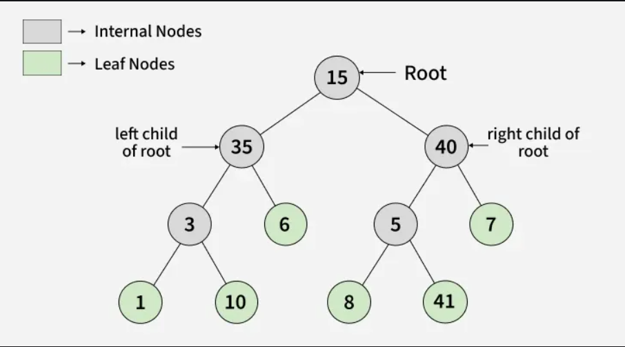

### **Representasi Pohon Biner**

Setiap node dalam Pohon Biner memiliki tiga bagian:

- Data
- Penunjuk ke anak sebelah kiri
- Penunjuk ke anak yang tepat

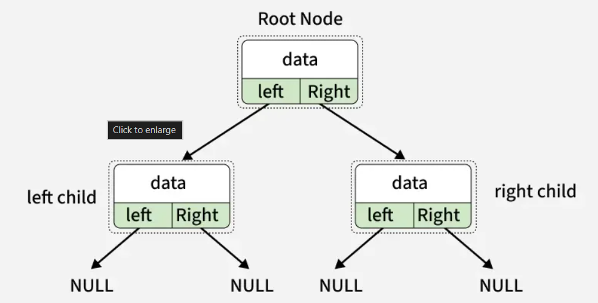

### **Terminologi dalam Pohon Biner**

- **Node Induk :** Node yang merupakan leluhur langsung dari sebuah node (node anaknya).
- **Node Anak :** Sebuah node yang merupakan keturunan langsung dari node lain (induknya).
- **Leluhur suatu node :** Semua node pada jalur dari root ke node tersebut (termasuk node itu sendiri).
- **Keturunan dari suatu node :** Semua node yang terletak di dalam subpohon yang berakar pada node tersebut (termasuk node itu sendiri).
- **Subpohon dari sebuah simpul :** Sebuah pohon yang terdiri dari simpul tersebut sebagai akar dan semua keturunannya.
- **Edge**: Hubungan/koneksi antara node induk dan node anaknya.
- **Jalur dalam pohon biner:** Urutan simpul yang dihubungkan oleh sisi dari satu simpul ke simpul lainnya.
- **Node Daun :** Sebuah node yang tidak memiliki anak atau kedua anaknya bernilai null.
- **Node Internal :** Sebuah node yang memiliki setidaknya satu anak.
- **Kedalaman/Tingkat Node :** Jumlah sisi pada jalur dari node akar ke node tersebut. Kedalaman/tingkat node akar adalah nol.
- **Tinggi Pohon Biner :** Jumlah sisi pada jalur terpanjang dari akar ke daun.

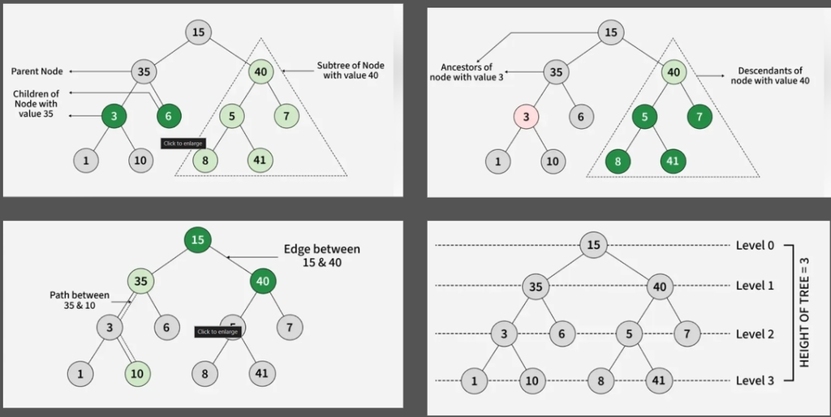

### **Membuat/Mendeklarasikan Node pada Pohon Biner**

Sintaks untuk mendeklarasikan sebuah Node pada Pohon Biner dalam berbagai bahasa:

```python
# Node structure
class Node:
    def __init__(self, key):
        self.left = None
        self.right = None
        self.val = key
```

**Membuat Pohon Biner**

Pada contoh ini, kita akan mempelajari cara membuat Pohon Biner dengan empat node yaitu 2, 3, 4, 5.

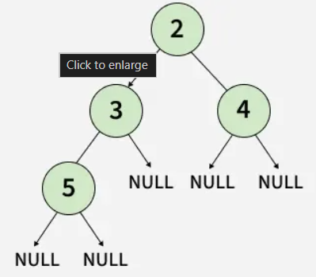

```python
# Node structure
class Node:
    def __init__(self, d):
        self.data = d
        self.left = None
        self.right = None

# Initialize and allocate memory for tree nodes
firstNode = Node(2)
secondNode = Node(3)
thirdNode = Node(4)
fourthNode = Node(5)

# Connect binary tree nodes
firstNode.left = secondNode
firstNode.right = thirdNode
secondNode.left = fourthNode
```

Pada kode di atas, kita telah membuat empat node pohon yaitu firstNode , secondNode , thirdNode , dan fourthNode dengan nilai masing-masing 2 , 3 , 4 , dan 5 , lalu membuat tautan antar node tersebut sesuai dengan struktur pohon yang diberikan.

## **Sifat-Sifat Pohon Biner**

- Jumlah maksimum node pada level L dari pohon biner adalah 2L .
- Jumlah maksimum node dalam pohon biner dengan tinggi H adalah 2 H+1 – 1.
- Jumlah total node daun dalam pohon biner = jumlah total node dengan 2 anak + 1.
- Dalam Pohon Biner dengan N simpul, tinggi minimum yang mungkin atau jumlah level minimum adalah ⌊log 2 N⌋.
- Pohon biner dengan L daun memiliki setidaknya ⌈log 2 L⌉+ 1 level.

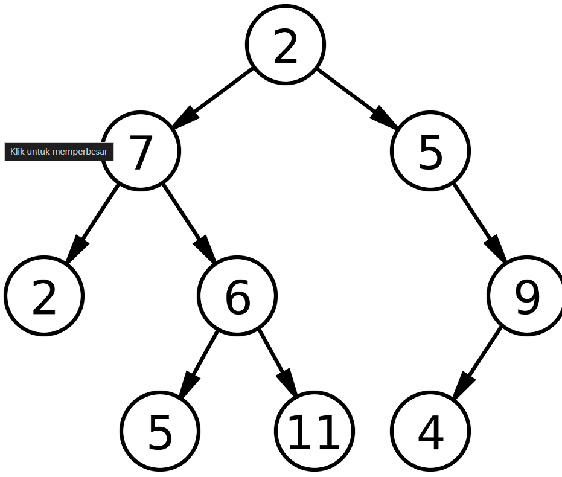

### **Sifat-Sifat Pohon Biner**

**1. Jumlah Node Maksimum pada Level 'l'** Pohon biner dapat memiliki paling banyak 2 l simpul pada level l .

- Definisi Level: Jumlah sisi pada jalur dari akar ke sebuah simpul. Akar berada pada level 0 .
- Pembuktian dengan Induksi:

*Kasus dasar: Untuk akar ( l = 0 ), node = 2 0 = 1.*

*Langkah induktif: Jika level l memiliki 2 l node, maka level berikutnya memiliki paling banyak dua kali lipat jumlah node tersebut:*

**2×2 l = 2 l+1**

**2. Jumlah Maksimum Node dalam Pohon Biner dengan Tinggi 'h'** Pohon biner dengan tinggi h dapat memiliki paling banyak 2 h+1 - 1 simpul.

- **Definisi Tinggi:** Jalur terpanjang dari akar ke simpul daun. Harap dicatat bahwa pohon dengan hanya satu simpul akar dianggap memiliki tinggi 0 dan pohon kosong (atau akarnya NULL) dianggap memiliki tinggi "-1".

*Penurunan Rumus: Sebuah pohon memiliki jumlah simpul maksimum ketika semua level terisi penuh . Menjumlahkan simpul di setiap level:*

1 + 2 + 4 + ... + 2h = 2h + 1 - 1

- **Konvensi Tinggi Alternatif:** Beberapa buku menganggap pohon dengan hanya satu simpul akar memiliki tinggi 1 dan pohon kosong (atau akarnya NULL) memiliki tinggi 0, sehingga rumusnya menjadi 2h - 1.

**3. Tinggi Minimum untuk 'N' Node** Tinggi minimum yang mungkin untuk N node adalah ⌊log 2 N⌋ .

**Penjelasan:** Pohon biner dengan tinggi h dapat memiliki paling banyak 2 h+1 - 1 node.

Menyusun ulang:

N ≤ 2 h+1 − 1 2 h+1 ≥ N+1 h ≥ log 2 (N+1) - 1 (Mengambil log 2 dari kedua sisi) h ≥ ⌊log 2 N⌋

Ini berarti pohon biner dengan N simpul harus memiliki setidaknya ⌊log 2 N⌋ level .

**4. Tingkat Minimum untuk Daun 'L'** Pohon biner dengan L daun harus memiliki setidaknya ⌊log 2 L⌋ level.

Mengapa? Pohon memiliki jumlah daun terbanyak ketika semua tingkat terisi penuh .

*Dari Properti 1:* *L ≤ 2 l ( l adalah tingkat di mana daun muncul)*

*Menyelesaikan untuk l :* *l min = ⌊log 2 L⌋*

Ini memberikan tingkat minimum yang dibutuhkan untuk menampung daun L.

**5. Node dengan Dua Anak vs. Node Daun**

Dalam pohon biner penuh (di mana setiap simpul memiliki 0 atau 2 anak), jumlah simpul daun (L) selalu satu lebih banyak daripada simpul internal (T) yang memiliki dua anak :

*L=T+1*

*Bukti:*

*Pohon biner penuh memiliki total 2 h+1 - 1 node.*

*Node internal: T =2 h (2−1) − 1= 2 h - 1.*

*Disederhanakan menjadi L=T+1*

**6. Jumlah Sisi pada Pohon Biner** Pada pohon biner tak kosong dengan n simpul, jumlah total sisinya adalah n - 1 .

*Setiap node (kecuali root) memiliki tepat satu induk , dan setiap koneksi induk-anak mewakili sebuah edge .*

*Karena ada n simpul , maka pasti ada n - 1 sisi .*

## **Properti Utama Tambahan**

Hubungan Node Setiap node memiliki paling banyak dua anak .

- 0 anak → Simpul Daun
- 1 anak → Node Unary
- 2 anak → Node Biner

**Operasi pada Pohon Biner**

Berikut adalah daftar operasi umum yang dapat dilakukan pada pohon biner:

1. Penelusuran: Penelusuran Depth-First Search (DFS) dan Penelusuran Breadth-First Search (BFS) 2. Pencarian: Mencari simpul dalam Pohon Biner 3. Penyisipan dan Penghapusan: Prasyarat: Penelusuran Level Order , Penyisipan dalam Pohon Biner dan Penghapusan dari Pohon Biner

**Keunggulan Pohon Biner**

- Pencarian Efisien: Pohon Pencarian Biner (variasi dari Pohon Biner) efisien dalam mencari elemen tertentu, karena setiap node memiliki paling banyak dua node anak jika dibandingkan dengan linked list dan array.
- Efisien Memori: Pohon biner membutuhkan memori yang lebih sedikit dibandingkan dengan struktur data pohon lainnya, oleh karena itu efisien dalam penggunaan memori.
- Pohon biner relatif mudah diimplementasikan dan dipahami karena setiap simpul memiliki paling banyak dua anak, anak kiri dan anak kanan.

**Kelemahan Pohon Biner**

- Struktur terbatas: Pohon biner terbatas pada dua node anak per node, yang dapat membatasi kegunaannya dalam aplikasi tertentu. Misalnya, jika sebuah pohon membutuhkan lebih dari dua node anak per node, struktur pohon yang berbeda mungkin lebih sesuai.
- Ketidakefisienan ruang: Pohon biner dapat menjadi tidak efisien dalam penggunaan ruang jika dibandingkan dengan struktur data lain seperti array dan linked list. Hal ini karena setiap node membutuhkan dua referensi atau pointer anak, yang dapat menyebabkan beban memori yang signifikan untuk pohon yang besar.

**Aplikasi Pohon Biner**

- Pohon biner dapat digunakan untuk merepresentasikan data hierarkis.
- Pohon pengkodean Huffman digunakan dalam algoritma kompresi data.
- Berguna untuk pengindeksan yang tersegmentasi di basis data, berguna untuk menyimpan cache di dalam sistem.
- Pohon biner dapat digunakan untuk mengimplementasikan pohon keputusan, yaitu jenis algoritma pembelajaran mesin yang digunakan untuk klasifikasi dan analisis regresi.

# **Jenis-jenis Pohon Biner**

- Pohon Biner Penuh → Setiap simpul bukan daun memiliki tepat dua anak .
- Pohon Biner Lengkap → Semua level terisi penuh kecuali mungkin level terakhir , yang diisi dari kiri ke kanan .
- Pohon Biner Sempurna → Setiap level terisi penuh , dan semua daun berada pada kedalaman yang sama .
- Pohon Biner Seimbang → Subpohon kiri dan kanan berbeda tingginya paling banyak 1 .

Pohon biner adalah struktur data pohon di mana setiap simpul memiliki paling banyak dua anak . Kedua anak ini biasanya disebut sebagai anak kiri dan anak kanan . Struktur ini banyak digunakan dalam aplikasi seperti pohon pencarian biner dan tumpukan (heap).

## **Jenis-jenis Pohon Biner**

***1. Berdasarkan jumlah anak:**

Pohon biner disebut pohon biner penuh jika setiap simpul memiliki 0 atau 2 anak. Kita juga dapat mengatakan bahwa pohon biner penuh adalah pohon biner di mana semua simpul kecuali simpul daun memiliki dua anak.

Pohon biner penuh adalah jenis pohon biner khusus di mana setiap simpul induk/simpul internal memiliki dua anak atau tidak memiliki anak sama sekali. Pohon ini juga dikenal sebagai pohon biner sejati.

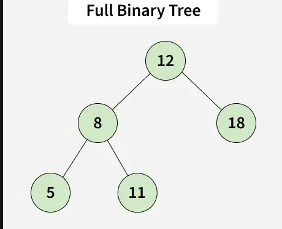

**Pohon yang mengalami degenerasi (atau patologis)**

Pohon di mana setiap simpul internal memiliki satu anak. Pohon seperti ini memiliki performa yang sama dengan linked list. Pohon yang degeneratif atau patologis adalah pohon yang hanya memiliki satu anak, baik di sebelah kiri maupun kanan.

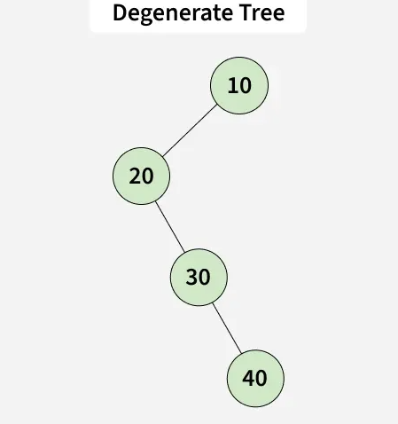

**Pohon Biner Miring**

Pohon biner miring adalah pohon patologis/degeneratif di mana pohon tersebut didominasi oleh simpul kiri atau simpul kanan. Dengan demikian, ada dua jenis pohon biner miring: pohon biner miring kiri dan pohon biner miring kanan. Lihat artikel ini untuk membaca lebih lanjut tentang Pohon Biner Miring.

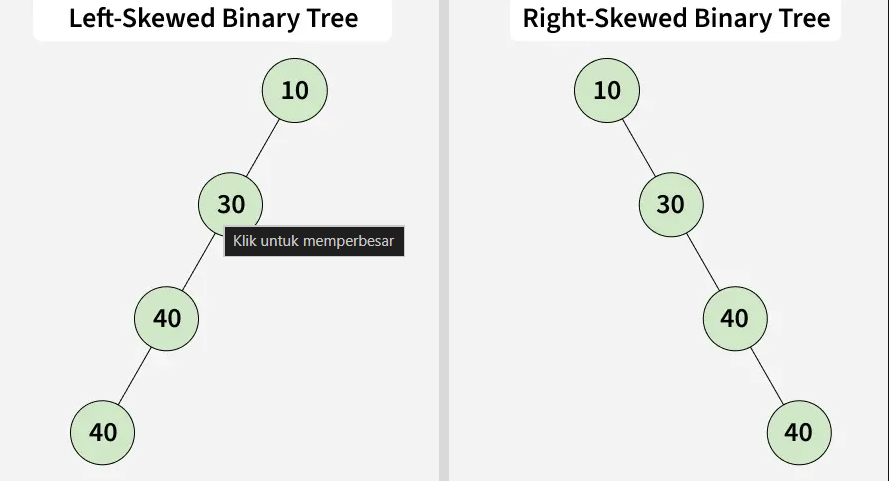

## **2. Berdasarkan tingkat penyelesaian:**

- Pohon Biner Lengkap
- Pohon Biner Sempurna
- Pohon Biner Seimbang

**Pohon Biner Lengkap**

Pohon biner disebut pohon biner lengkap jika semua level terisi penuh kecuali mungkin level terakhir, dan level terakhir diisi dari sisi kiri.

Pohon biner lengkap sama seperti pohon biner penuh, tetapi dengan dua perbedaan utama:

- Setiap level kecuali level terakhir harus diisi sepenuhnya.
- Semua elemen daun harus condong ke kiri.

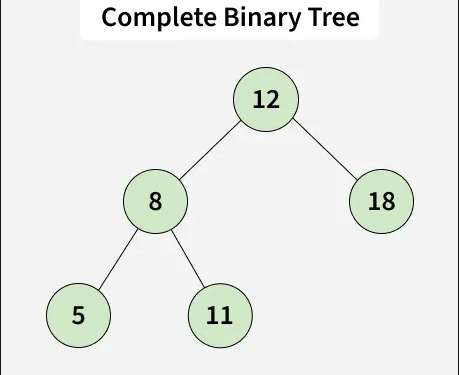

**Pohon Biner Sempurna**

Pohon biner adalah Pohon Biner Sempurna di mana semua simpul internal memiliki dua anak dan semua simpul daun berada pada level yang sama. Pohon biner sempurna adalah jenis pohon biner di mana setiap simpul internal memiliki tepat dua simpul anak dan semua simpul daun berada pada level yang sama.

Pada Pohon Biner Sempurna, jumlah node daun adalah jumlah node internal ditambah 1. Lihat artikel ini untuk membaca lebih lanjut tentang Pohon Sempurna.

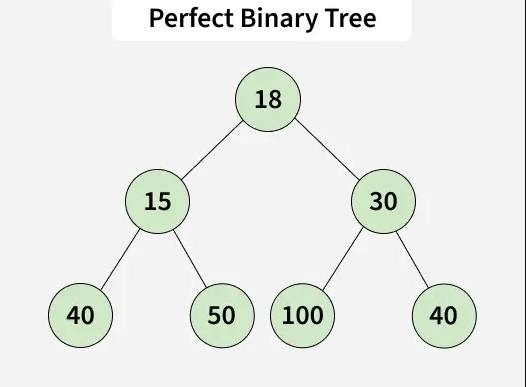

**Pohon Biner Seimbang**

Pohon biner dikatakan seimbang jika tinggi pohon tersebut adalah O(log n) di mana n adalah jumlah node.

Sebagai contoh, pohon AVL mempertahankan tinggi O(log n) dengan memastikan bahwa perbedaan antara tinggi subpohon kiri dan kanan setiap simpul paling banyak adalah 1.

Berikut ini adalah contoh pohon biner seimbang. Di sini, d = kedalaman simpul = |Tinggi anak kiri - Tinggi anak kanan|.

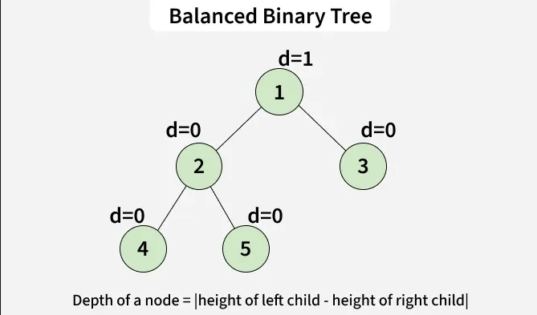

## **Beberapa Jenis Pohon Istimewa:**

Berdasarkan nilai node, Pohon Biner dapat diklasifikasikan ke dalam tipe-tipe khusus berikut:

1. Pohon Pencarian Biner
2. Pohon AVL
3. Pohon Merah Hitam
4. Pohon B
5. Pohon B+

Gambar di bawah ini menunjukkan beberapa kasus khusus penting dari pohon biner:

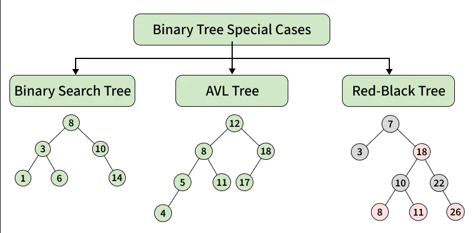

**1. Pohon Pencarian Biner**

Binary Search Tree (BST) adalah struktur data pohon biner berbasis node yang memiliki sifat-sifat berikut:

Subpohon sebelah kiri suatu node hanya berisi node-node dengan kunci yang lebih kecil daripada kunci node tersebut. Subpohon kanan dari sebuah node hanya berisi node-node dengan kunci yang lebih besar daripada kunci node tersebut. Subpohon kiri dan kanan juga harus berupa pohon pencarian biner.

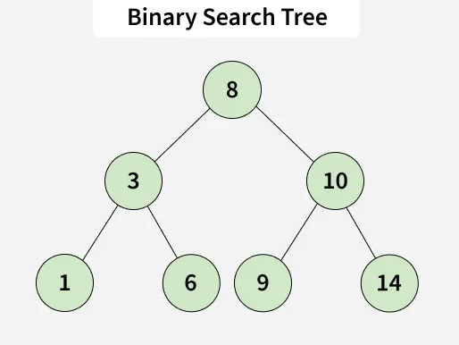

**2. Pohon AVL**

Pohon AVL adalah Pohon Pencarian Biner ( BST ) yang menyeimbangkan diri sendiri di mana perbedaan antara tinggi subpohon kiri dan kanan dari semua simpul paling banyak adalah 1. Pohon di bawah ini adalah AVL karena perbedaan antara tinggi subpohon kiri dan kanan untuk setiap simpul ≤ 1.

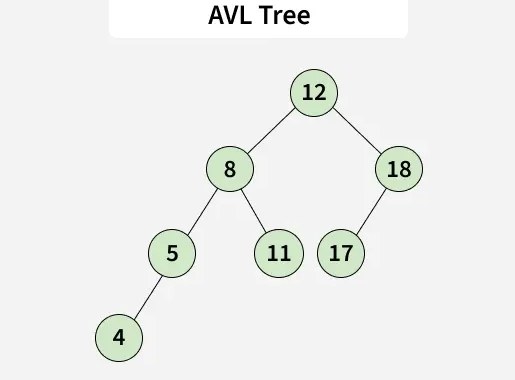

**3. Pohon Merah Hitam**

Pohon merah-hitam adalah jenis pohon pencarian biner yang menyeimbangkan diri sendiri di mana setiap simpul memiliki bit tambahan , dan bit tersebut sering diinterpretasikan sebagai warna (merah atau hitam). Warna-warna ini digunakan untuk memastikan bahwa pohon tetap seimbang selama penyisipan dan penghapusan. Meskipun keseimbangan pohon tidak sempurna, keseimbangan tersebut cukup baik untuk mengurangi waktu pencarian dan mempertahankannya sekitar O(log n), di mana n adalah jumlah total elemen dalam pohon.

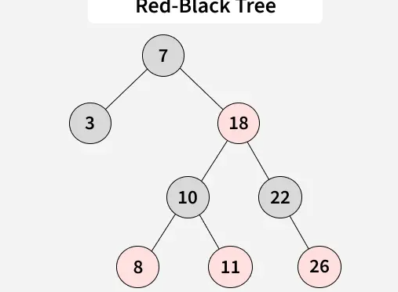

**4. B - Pohon** B-Tree adalah pohon pencarian yang menyeimbangkan diri sendiri, dirancang untuk operasi penyisipan, penghapusan, dan pencarian yang efisien pada sistem berbasis disk. Setiap node dapat memiliki banyak kunci dan anak, kunci di dalam sebuah node diurutkan, dan subpohon di antara kunci menyimpan nilai dalam rentang kunci tersebut. Struktur ini memastikan keseimbangan dan meminimalkan tinggi untuk akses cepat bahkan dengan kumpulan data yang besar.

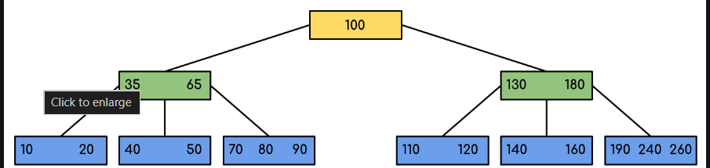

**5. Pohon B+** B+ Tree adalah perluasan dari B-Tree di mana semua data hanya disimpan di node daun, sedangkan node internal hanya menyimpan kunci untuk pengindeksan. Node daun dihubungkan secara berurutan, membentuk daftar berantai yang memungkinkan kueri rentang yang efisien dan penelusuran terurut.

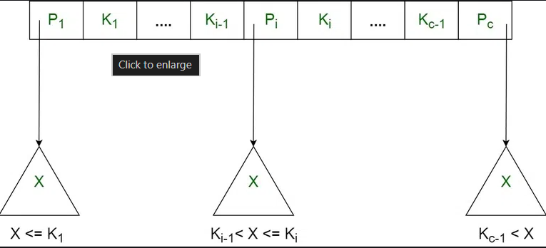

# **LATIHAN CODE**

Soal 1: Konstruktor dan Inisialisasi Tree Instruksi: Buatlah class Node dan class BST yang memiliki konstruktor untuk menginisialisasi root. Tambahkan fungsi is_empty() untuk mengecek apakah tree belum memiliki data.

```python
class Node:
    def __init__(self, data):
        self.data = data
        self.left = None
        self.right = None

class BST:
    def __init__(self):
        self.root = None

    def is_empty(self):
        return self.root is None

    def display_status(self):
        if self.is_empty():
            print("Tree saat ini kosong.")
        else:
            print(f"Root saat ini adalah: {self.root.data}")

# Uji coba
tree = BST()
tree.display_status()
```

Soal 2: Insert Data secara Rekursif dengan Validasi Instruksi: Buatlah fungsi insert yang memasukkan data sesuai aturan BST (kiri < root, kanan > root) dan jangan masukkan data yang duplikat.

```python
class BST:
    # ... (lanjutan dari Soal 1)
    def insert(self, data):
        if self.root is None:
            self.root = Node(data)
        else:
            self._insert_recursive(self.root, data)

    def _insert_recursive(self, current, data):
        if data < current.data:
            if current.left is None:
                current.left = Node(data)
            else:
                self._insert_recursive(current.left, data)
        elif data > current.data:
            if current.right is None:
                current.right = Node(data)
            else:
                self._insert_recursive(current.right, data)
        else:
            print(f"Data {data} sudah ada, tidak dimasukkan.")
```

```python
class BST:
    # ... (lanjutan)
    def traverse_inorder(self, node, result):
        if node:
            self.traverse_inorder(node.left, result)
            result.append(node.data)
            self.traverse_inorder(node.right, result)
        return result

    def traverse_preorder(self, node, result):
        if node:
            result.append(node.data)
            self.traverse_preorder(node.left, result)
            self.traverse_preorder(node.right, result)
        return result
```

Soal 4: Pencarian Data (Search) Instruksi: Buatlah fungsi search yang mengembalikan True jika data ada, dan False jika tidak, dengan logika rekursif.

```python
class BST:
    # ... (lanjutan)
    def search(self, data):
        return self._search_recursive(self.root, data)

    def _search_recursive(self, node, data):
        if node is None: return False
        if node.data == data: return True
        if data < node.data:
            return self._search_recursive(node.left, data)
        return self._search_recursive(node.right, data)
```

Soal 5: Mencari Nilai Minimum dan Maksimum Instruksi: Karena sifat BST yang terurut, buatlah fungsi untuk mencari nilai terkecil (paling kiri) dan terbesar (paling kanan).

```python
class BST:
    # ... (lanjutan)
    def find_min(self):
        current = self.root
        while current.left:
            current = current.left
        return current.data

    def find_max(self):
        current = self.root
        while current.right:
            current = current.right
        return current.data
```

Soal 6: Menghitung Jumlah Node (Size) Instruksi: Hitung total seluruh node yang ada di dalam pohon menggunakan teknik divide and conquer.

```python
class BST:
    # ... (lanjutan)
    def get_size(self, node=None):
        if node is None: node = self.root
        if node is None: return 0
        return 1 + self.get_size(node.left) + self.get_size(node.right)
```

Soal 7: Menghitung Tinggi Pohon (Height) Instruksi: Tentukan kedalaman atau tinggi pohon dengan mencari jalur terpanjang dari root ke leaf.

```python
class BST:
    # ... (lanjutan)
    def get_height(self, node=None):
        if node is None: node = self.root
        if node is None: return -1
        return 1 + max(self.get_height(node.left), self.get_height(node.right))
```

```python
class BST:
    # ... (lanjutan)
    def delete(self, data):
        self.root = self._delete_recursive(self.root, data)

    def _delete_recursive(self, node, data):
        if node is None: return node
        if data < node.data: node.left = self._delete_recursive(node.left, data)
        elif data > node.data: node.right = self._delete_recursive(node.right, data)
        else:
            if not node.left: return node.right
            elif not node.right: return node.left
            temp = self._min_value_node(node.right)
            node.data = temp.data
            node.right = self._delete_recursive(node.right, temp.data)
        return node

    def _min_value_node(self, node):
        current = node
        while current.left: current = current.left
        return current
```

Soal 9: Level-Order Traversal (BFS) Instruksi: Tampilkan data berdasarkan level (lantai), dari atas ke bawah, kiri ke kanan menggunakan Queue.

```python
class BST:
    # ... (lanjutan)
    def level_order(self):
        if not self.root: return
        queue = [self.root]
        while queue:
            node = queue.pop(0)
            print(node.data, end=" ")
            if node.left: queue.append(node.left)
            if node.right: queue.append(node.right)
```

Soal 10: Mencari Jalur ke Node Tertentu (Path Finder) Instruksi: Tampilkan jalur atau langkah-langkah yang diambil dari root untuk menemukan node tertentu.

```python
class BST:
    # ... (lanjutan)
    def find_path(self, data):
        path = []
        current = self.root
        while current:
            path.append(current.data)
            if current.data == data:
                return " -> ".join(map(str, path))
            elif data < current.data:
                current = current.left
            else:
                current = current.right
        return "Jalur tidak ditemukan."
```